# Fathers’ involvement in children’s language development: A meta-analysis

September 8, 2018

## Introduction

Interactions with caregivers drive children’s language development  
([Pancsofar & Vernon-Feagans, 2006](https://doi.org/10.1016/j.appdev.2006.08.003))

Fathers play unique role  
(Cabrera & Tamis-LeMonda, 2013; [Varghese & Wachen, 2016](https://doi.org/10.1080/01494929.2015.1099587))

- Through relationship with the mother
- Indirectly, providing resources
- *Directly, through interactions with children*

## Direct involvement

Fathers use more varied/challenging language than mothers  
([Tamis-LeMonda, Baumwell, & Cristofaro, 2012](https://doi.org/10.1177/0142723711419321))

- More clarification requests (“wh- questions”)  
  ([Rowe et al., 2004](https://doi.org/10.1111/j.1467-9507.2004.000267.x))
- Do not adjust conversation topic to child  
  ([Abkarian et al., 2003](http://www.mensstudies.info/OJS/index.php/FATHERING/article/download/185/pdf_1))

This expands children’s vocabulary (zone of proximal development)  
([Pancsofar & Vernon-Feagans, 2010](https://doi.org/10.1016/j.ecresq.2010.02.001))

## Previous meta-analysis

Correlation between fathers’ direct involvement and children’s language outcomes

- Previous meta-analysis covered studies until 2008  
  ([McWayne, Downer, Campos, & Harris, 2013](https://doi.org/10.1080/10409289.2013.746932))
- Average correlation: .08 (5 effect sizes)

**Recently: burgeoning interest in fatherhood!**

Time to update this estimate

## Moderators

Meta-analysis intended to summarize highly similar studies

Often (ab?)used to summarize diverse bodies of research

Differences between studies can be coded as moderators

Problem with classic meta-regression:

- Lacks power to identify relevant moderators
- Overfitting
- Forget about including interactions!

## Metaforest

Machine-learning based technique to identify relevant moderators

High power with as few as 20 studies

Controls overfitting

Accounts for interactions and non-linear effects

[Van Lissa, 2017](https://osf.io/khjgb/)

## Methods

Electronic databases:

- Web of Science
- PsychInfo
- ERIC

Articles screened: 7185

Relevant articles: 144

Of these, 46 reported a total of 377 correlation coefficients

## Dataset

Observed effect sizes ranged from -0.65 to 0.73  
\(M_r = 0.07\), \(SD = 0.22\)

Sample sizes ranged from 8 to 5190  
\(M_n = 185.37\), \(SD = 413.82\)

## Standard meta-analysis

Multilevel meta-analysis for dependent effect sizes  
(Van den Noortgate et al., 2013)

**Overall effect size:**

\(\hat{\rho} = 0.11\), 95% CI [0.07, 0.15]

**Tests for residual heterogeneity**

- \(Q(376) = 2666.44, p = 0\)
- Total \(I^2 = 88.01\%\)
- Between studies: \(I^2_b = 31.78\%\)
- Within studies: \(I^2_w = 56.22\%\)

## Publication bias

[interactive chart not shown]

Funnel plot asymmetry test: \(z = -1.24, p = 0.22\)

File drawer analysis: \(K = 2.6823\times 10^{4}\)

## Moderator analyses

## Metaforest analysis

Metaforest analysis  
([R-package by Van Lissa, 2017](https://cran.r-project.org/package=metaforest))

Dependent effect sizes: Clustered bootstrapping

Unbiased prediction error: Two parallel forests (10.000 trees)  
([Janitza, Celik, & Boulesteix, 2016](https://doi.org/10.1007/s11634-016-0276-4))

## Recursive pre-selection

**Solution:** Recursive pre-selection; 100 replications

Algorithm:

1. Start with all moderators
2. Conduct random-effects metaforest, with 2000 trees
3. **If** no moderators have negative importance values, or only one moderator, return the resulting model  
   **Else**, drop the variable with most negative variable importance, go back to Step 2

Retained moderators selected in 30%+ of replications

## Recursive pre-selection results

[output not shown]

## Recursive pre-selection, full results

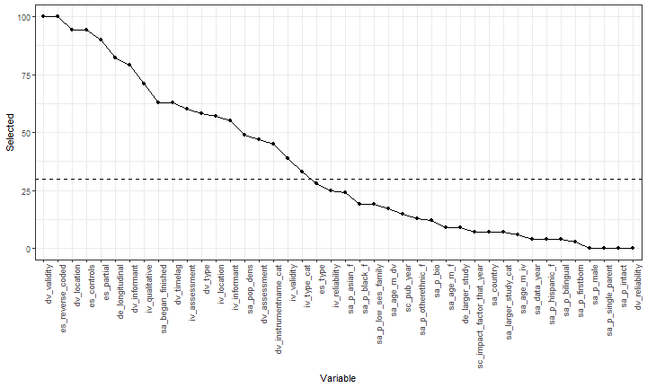

## Model tuning

Finding optimal analysis settings

- 10-fold (clustered) cross-validation
- Settings considered:
  - Weights (“random”, “fixed”, “uniform”),
  - Candidate variables (2, 4, 6)
  - Min. node size = (2, 4, 6)
- Select model with smallest prediction error (RMSE)

Optimal model: uniform weights, 4 candidate variables, min node size 2

## Results

Cross-validated \(R^2_{cv} = 0.09\)

Clear evidence of model convergence:

[figure not shown]

## Variable importance

Contribution to predictive performance; encompasses interactions/non-linear effects

[figure not shown]

## Bivariate marginal associations 1/2

“Main effects”, averaging over all other predictors

[figure not shown]

## Bivariate marginal associations 2/2

[figure not shown]

## Conclusions

**Substantive**

- Association might be stronger than thought before (.11 vs .08)
- Which aspects of children’s language do fathers influence?  
  (Cabrera & Tamis-LeMonda, 2013)
- Stronger effects for **generative-** than **receptive** language

**Methodological**

- Research at home > Lab/school (ecological validity?)
- Assessments/observations > questionnaires
- Trained researchers > parent/self-reports

**Statistical**

- Cross-sectional > longitudinal (dissipation over time)
- High dropout rate: Higher effect size (selection effect)
- Partial correlations tend to be stronger (phacking?)

## Implications for adolescence

Fathers continue to be relevant, outcome variables change

E.g., father involvement associated with adolescents’ academic achievement  
([Meta-analysis by Jeynes, 2014](http://sci-hub.tw/10.1177/0042085914525789))

Important to account for moderators in meta-analysis

MetaForest is a powerful technique to explore between-study heterogeneity

## Further information

All data and syntax on https://osf.io/dz39y/

This presentation live at https://cjvanlissa.github.io/meta_fathers